# Etienne Bacher

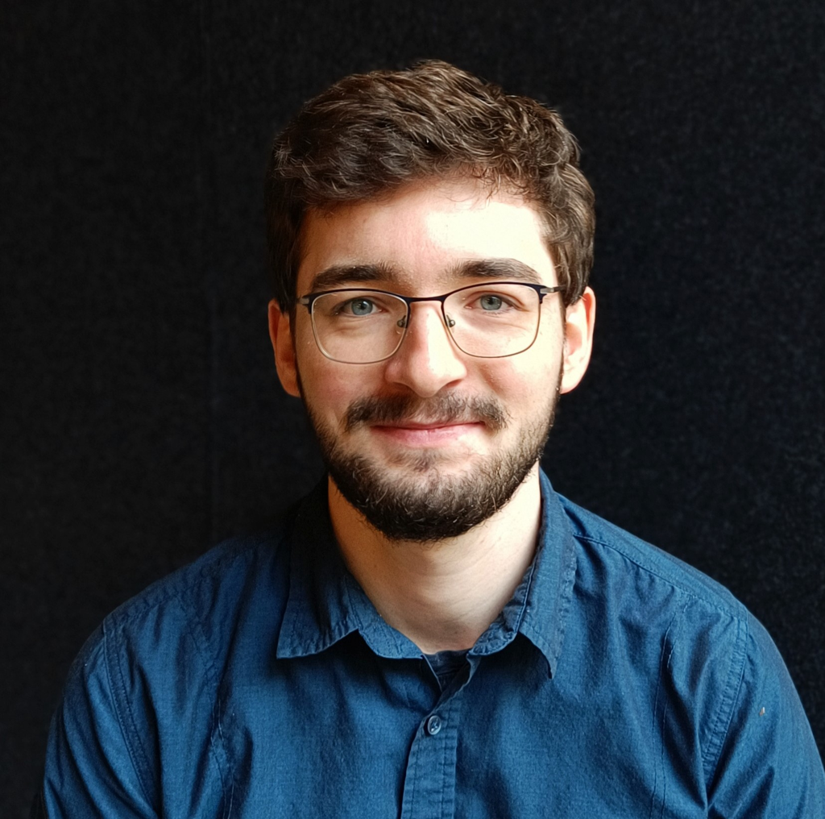

Hi there! I’m Etienne Bacher.

I am a Research Software Engineer working at University College London on the [Palaeoverse](https://palaeoverse.org/), a collection of R packages for palaeobiologists.

Before that, I completed a PhD in Economics as part of the [Doctoral Team Unit ACROSS](https://sites.google.com/view/fredericdocquier/xingb-blog/across) at the Luxembourg Institute for Socio-Economic Research (LISER). I focused on the relationship between cross-border mobility, attitudes and political preferences using both contemporaneous and historical data.

I then worked as a Research Associate at LISER, helping on the INSKILL project to study the effect of Artificial Intelligence on the labour market in Western Europe.

In parallel, I develop or contribute to many R packages, all of which you can find on [my GitHub profile](https://github.com/etiennebacher/). I also write occasional blog articles about R and I have given some training on several topics, available in the “Software” tab above.

If you want to contact me, the best way to do so is by email.

[figure not shown]

[etiennebacher](https://github.com/etiennebacher/)

[figure not shown]

[[at]etiennebacher](https://mastodon.social/@etiennebacher)

[figure not shown]

etiennebacher.bsky.social

[figure not shown]

etienne.bacher[at]protonmail.com